# Support-Vector-Machines = Maximum Margin Classification

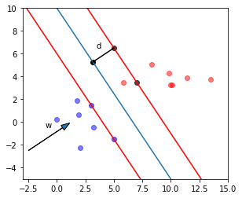

Im 2-dimensionalen Raum haben wir die Variablen x, y. Alle Punkte auf einer Geraden (separating plane) bekommt man: $$ a + b\cdot x = c\cdot y$$
Trivialerweise ist $$c=1$$ meist gültig.
Umgekehrt kann man die Gerade auch als die Menge aller Punkte definieren, die folgender Bedingung genügen:
$$ a + b\cdot x + c\cdot y = 0$$
Im trivialen Fall wäre $$c=-1$$

Für alle Punkte unterhalb der Gerade gilt: $$ a + b\cdot x + c\cdot y < 0$$ und für alle Punkte oberhalb der Geraden gilt: $$ a + b\cdot x + c\cdot y > 0$$

Für die Klassification gilt, dass die Klassen immer mit $-1$ und $1$ benannt werden. Ein neuer Punkt $(x, y)$ wird klassifiziert: $$\hat{\text{pred}} = \text{sign}(a + b\cdot x + c\cdot y)$$

### Aenderung der Schreibweise:

Weil wir kein Regressionsproblem haben, sondern ein Klassifikationsproblem, benennen wir im obigen Beispiel die Koeffizienten und die Variablen um: $$\hat{\text{pred}} = \text{sign}(b + \omega_1\cdot x_i + \omega_2\cdot x_2)$$ und in Vektorschreibweise: $$\hat{\text{pred}} = \text{sign}(b + \mathbf{\omega}\mathbf{x})$$

Es kann gezeigt werden, dass der Vektor $\mathbf{\omega}$ senkrecht auf die Trennungs-Ebene (in der Graphik oben die mittlere Gerade) steht. Dies habe ich als Pfeil eingezeichnet.

Nun soll eine Ebene gefunden werden, deren **margin maximal** ist; als margin wird der Abstand zu den nähesten Daten-Punkten bezeichnet. Die Datenpunkte, die auf den margins zu liegen kommen heissen **support vectors**. Die Enfernung dieser Punkte von der Trennlinie kann angegeben werden:

\begin{equation} d= y_i(\mathbf{\omega}\mathbf{x}_i + b);\quad \quad y_i \in \{-1, 1\}, \end{equation}

wobei $y_i$ ändert das Vorzeichen, so dass die Distanz immer positiv ist.

Für alle Punkte $\mathbf{x_i}$, die genau die Distanz 1 haben gilt:

\begin{eqnarray} 1 =& y_i(\mathbf{\omega}\mathbf{x}_i + b)\\ \frac{1}{\| \mathbf{\omega}\| } =& \left|\frac{\mathbf{\omega}\mathbf{x}_i}{\|\mathbf{\omega}\|} + \frac{b}{\|\mathbf{\omega}\|}\right| \end{eqnarray}

$\|\mathbf{\omega}\|$ ist die Länge des Vektors $\mathbf{\omega}$, die sogenannte Vecktor-Norm. Teile ich einen Vektor durch seine Vektor-Norm, dann hat er genau die Länge $1$. Weil alle Punkte auf dem margin dieselbe Distanz zur Trennlinie haben und weil der margin symmetrisch ist muss

\begin{equation} p = \frac{2}{\|\mathbf{\omega}\|} \end{equation}

maximiert werden, um den margin möglichst gross zu machen.  
Der Abstand der beide support-vectors ist also indirekt proportional zur Länge des Vectors $\omega$. Als Minimierungs-Problem ergibt sich: \begin{equation} (\omega^*, b^*) = \text{argmin} \frac{1}{2}\|\mathbf{\omega}\| \end{equation} Damit haben wir die formulierung unseres maximum-margin classifiers:  
Finde $\mathbf{\omega}$ und $b$ so, dass:

- $\frac{1}{2}\omega^{T}\omega$ minimiert wird, für alle
- $(\mathbf{x}_i, y_i), y_i(\mathbf{\omega}\mathbf{x}_i + b) \geq 1$

Will man das lösen, ergibt sich ein quadratische Optimierungsproblem, welches mit Lagrange Multiplikatoren gelöst werden kann.

Die characteristische Gleichung ergibt sich zu: 1) $$\text{max}_{\alpha}\sum_i\alpha_i - \frac{1}{2}\alpha_i\alpha_j y_i y_j \mathbf{x}_i^{T} \cdot \mathbf{x}_j$$ 2) mit: $$\sum_i\alpha_i y_i = 0$$

Für das Verständnis der nachfolgenden Erklärungen zu kernels, ist der Ausdruck $\mathbf{x}_i^{T} \cdot \mathbf{x}_j$ entscheidend. Hierbei wird das Skalarprodukt eines jeden Daten-Punktes mit jedem anderen Daten-Punkt berechnet. Für normierte Vektoren $\mathbf{x}_i$ ist das Skalarprodukt ein Ähnlichkeitsmass (cosine-similarity, correlation-coefficient).

### Problem:

Der Ausdruck

\begin{equation} \mathbf{x}_i^{T} \cdot \mathbf{x}_j \end{equation}

zeigt, dass Support-Vecktor-Machines quadratisch mit der Anzahl der Trainings-Punkte skalieren. SVMs sind also für BigData nicht zu gebrauchen.

# Kernel-Trick

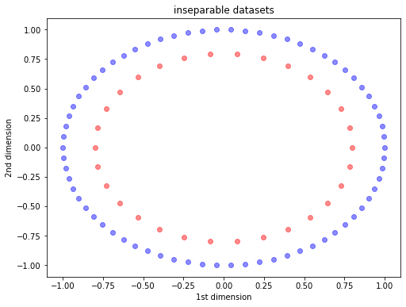

### project the data into 3 dimensions

$$\Phi(\mathbf{x})\rightarrow \mathbf{x}_1^{2}, \mathbf{x}_2^{2},\sqrt{2}\mathbf{x}_1\mathbf{x}_2$$

```python
x3 = np.sqrt(2) * x[:, 0] * x[:, 1]
x3 = x3.reshape((-1, 1))
mapped_x = np.concatenate((x ** 2, x3), axis=1)
mapped_x.shape
```

```
(100, 3)
```

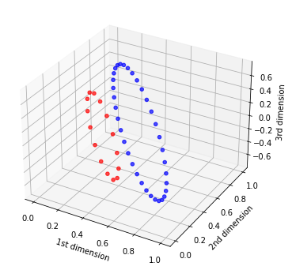

```python
fig = plt.figure(figsize = (8,6))
ax = fig.add_subplot(111, projection='3d')
ax.scatter(mapped_x[y==1, 0], mapped_x[y==1, 1], mapped_x[y==1, 2], color='red', alpha = 0.45)
ax.scatter(mapped_x[y==0, 0], mapped_x[y==0, 1], mapped_x[y==0, 2], color='blue', alpha = 0.45)
#plt.title('inseparable datasets')
ax.set_xlabel('1st dimension')
ax.set_ylabel('2nd dimension')
ax.set_zlabel('3rd dimension')
```

### just another projection into 3D

\begin{equation} \Phi(\mathbf{x})\rightarrow \mathbf{x}_i, \mathbf{x}_2, \sum_i^n \exp\left(-\frac{\|\mathbf{x}- \mathbf{x}_i\|^2}{2\sigma^2}\right) \end{equation}

```python
# not 100 % correct though
# https://stats.stackexchange.com/questions/63881/use-gaussian-rbf-kernel-for-mapping-of-2d-data-to-3d

from scipy.spatial.distance import pdist, squareform
from scipy import exp
pairwise_d = squareform(pdist(x, 'euclidean'))
K = exp(-pairwise_d **2 / (2 ** 2))
new_dim = np.sum(K, axis=1)
```

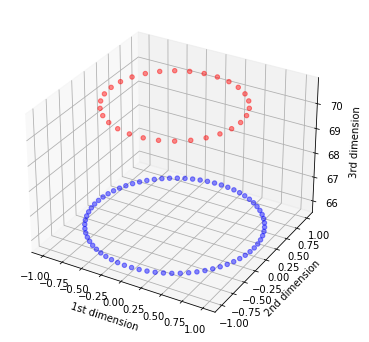

```python
fig = plt.figure(figsize = (8,6))
ax = fig.add_subplot(111, projection='3d')
ax.scatter(x[y==1, 0], x[y==1, 1], new_dim[y==1], color='red', alpha = 0.45)
ax.scatter(x[y==0, 0], x[y==0, 1], new_dim[y==0], color='blue', alpha = 0.45)
#plt.title('inseparable datasets')
ax.set_xlabel('1st dimension')
ax.set_ylabel('2nd dimension')
ax.set_zlabel('3rd dimension')
```

### Der kernel-Trick besteht genau darin, dass die Projektion in einen höher-dimensionalen Raum nicht vorgenommen werden muss

Wir erinnern die charakteristische Formel des maximal-margin classifiers:

1) $$\text{max}_{\alpha}\sum_i\alpha_i - \frac{1}{2}\alpha_i\alpha_j y_i y_j \mathbf{x}_i^{T} \cdot \mathbf{x}_j$$ 2) mit: $$\sum_i\alpha_i y_i = 0$$

Anstatt mit den urspr. Daten-Punkten $\mathbf{x}_i$ und $\mathbf{x}_j$ muss diese Gleichung jetzt für die Projektionen der Daten vorgenommen werden:

### unsere erste Projektion:

$\Phi(\mathbf{x})\rightarrow \mathbf{x}_1^{2}, \mathbf{x}_2^{2},\sqrt{2}\mathbf{x}_1\mathbf{x}_2$

einsetzen in die characteristische Gleichung für 2 Daten-Punkte $\mathbf{x}_i$ und $\mathbf{x}_j$: $$ \langle\Phi(\mathbf{x}_i),\Phi(\mathbf{x}_j)\rangle = $$ $$\langle[x_{i1}^{2},x_{i2}^{2}, \sqrt{2}x_{i1}x_{i2}],[x_{j1}^{2},x_{j2}^{2}, \sqrt{2}x_{j1}x_{j2}]\rangle = $$ $$ x_{i1}^{2}x_{j1}^{2} + x_{i2}^{2}x_{j2}^{2} +2 x_{i1}x_{i2}x_{j1}x_{j2} $$

### Trick: Es gibt eine einfachere Rechenvorschrift, die zum selben Ergebnis kommt. Das ist der Kernel-Trick

$$\langle\Phi(\mathbf{x}_i),\Phi(\mathbf{x}_j)\rangle = \langle\mathbf{x}_i,\mathbf{x}_j\rangle^{2} =$$$$\langle[x_{i1}, x_{i2}],[x_{j1}, x_{j2}]\rangle^{2} = $$$$(x_{i1}x_{j1} + x_{i2}x_{j2})^{2} = $$$$x_{i1}^{2}x_{j1}^{2} + x_{i2}^{2}x_{j2}^{2} + 2 x_{i1}x_{i2}x_{j1}x_{j2}$$

Man kann jetzt also schreiben:
$$ k(\mathbf{x_i}, \mathbf{x_j}) = \langle\mathbf{x}_i,\mathbf{x}_j\rangle^{2}$$

Für unsere charackteristische Gleichung könnten wir nun schreiben:
$$\text{max}_{\alpha}\sum_i\alpha_i - \frac{1}{2}\alpha_i\alpha_j y_i y_j k(\mathbf{x_i}, \mathbf{x_j})$$

Unser maximal-margin Classifier könnte als das Problem der 2 Ringe lösen, ohne explizit die Projektione in 3D vornehmen zu müssen.

Unterschied:  
1.Methode:

- Projektion in höher-dimensionalen Raum
- Multiplikation in höher-dimensionalen Raum

2.Method:

- Multiplikation im Ausgangs-Raum
- Quadratur des Ergebnisses

# What are kernels exactly?

Basically, kernels are similarity measures outside the usual Euclidean space.

For example, take the **radial basis function kernel**:

$$K(X_1, X_2) = \exp\left(-\frac{\|X_1 - X_2\|^2}{2\sigma^2}\right)$$

$\|X_1 - X_2\|$ is the Euclidean distance between the points $X_1$ and $X_2$ or between two vectors $\mathbf{x}_1$ and $\mathbf{x}_2$.  
If this distance is $0$, i.e. the two cases are actually identical, then the similarity -- as measured by the rbf-kernel -- is $1$:

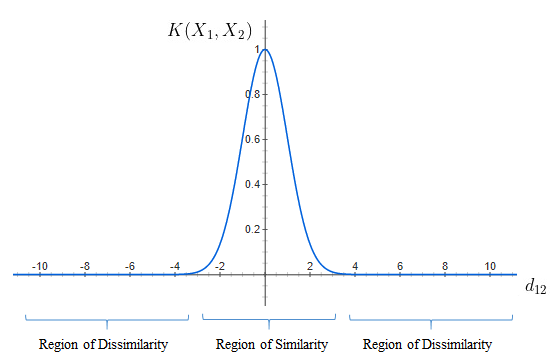

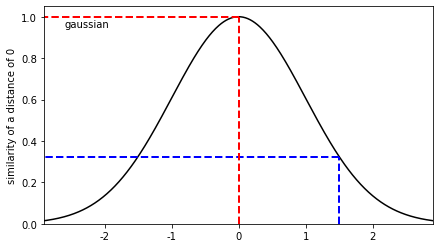

# Simple Kernel-Regression

Here, Kernels just define a neighborhood by similarity in kernel-space. For a certain point the values of its neighbors are weighted by similarity and then averaged.  
The Euclidean distance on the x-axis is transformed into a similarity-measure on the y-axis.

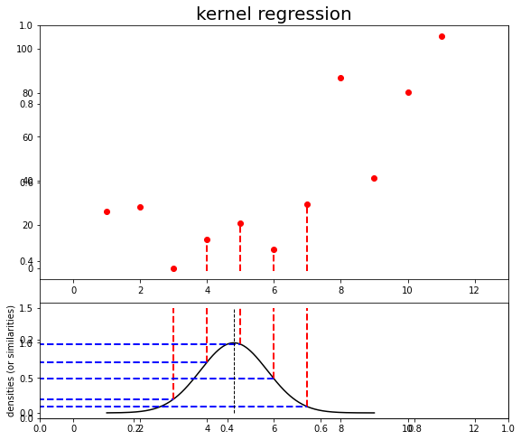

The prediction takes part at the center $x$ of the kernel. The similiarity to this center-point $x$ are evaluated for all points $x_i$ in the vicinity and the respective values $y_i$ are weighted by this similarity:

\begin{equation} \hat{m}(x) = \frac{\sum_i^n K_h(x - x_i)y_i}{\sum_i^n K_h(x - x_i)} \end{equation}

Here, $h$ is the bandwidth or the scale of the kernel. In the context of a gaussian kernel one could also say the **variance**.

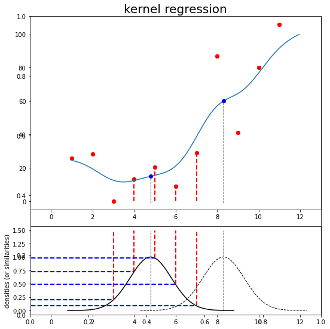

## How is the similarity-measure related to the support-vector-machine?

Remember that in the characteristic equation we had:

$$\mathbf{x}_i^{T} \cdot \mathbf{x}_j$$

This is the dot-product between two vectors. The dot-product for standardized vectors happens to coincide with the cosine-similarity that is identical to the correlation-coefficient $r$.  
With the kernel trick, we can now apply many different similarity-measures that hopefully help to distinguish our classes better than euclidean distance can do.  
Or, put in another way: we can either project our data into higher spaces and compute our conventional similarity measures in those spaces **or**: we use other similarity-measures that approximate the former approach.